# Wprowadzenie do statystyki, Rozkład z próby, Test t-Studenta

Jakub Paszulewicz

19/04/2021

# Rozkład średniej z próby

## Pobieranie próbek z zmiennej losowej o rozkładzie normalnym z znanymi parametrami mu/sigma

- Gdy dysponujemy **pojedynczą próbką**, wiemy jak możemy obliczyć maksymalną wiarygodność dla średniej z próby oraz odchylenia standardowego, $\hat \mu$ and $\hat \sigma$.
- Wyobraź sobie, że pobierasz wielokrotnie takie próbki; dla każdej takiej próbki, możesz obliczyć za każdym razem średnią. Możemy to zasymulować:

```r
x<-rnorm(100,mean=500,sd=50)
mean(x)
```

```
## [1] 505.2145
```

```r
x<-rnorm(100,mean=500,sd=50)
mean(x)
```

```
## [1] 501.2362
```

```r
x<-rnorm(100,mean=500,sd=50)
mean(x)
```

```
## [1] 498.8936
```

```r
x1<-rnorm(100000,mean=500,sd=50)
mean(x1)
```

```
## [1] 500.3655
```

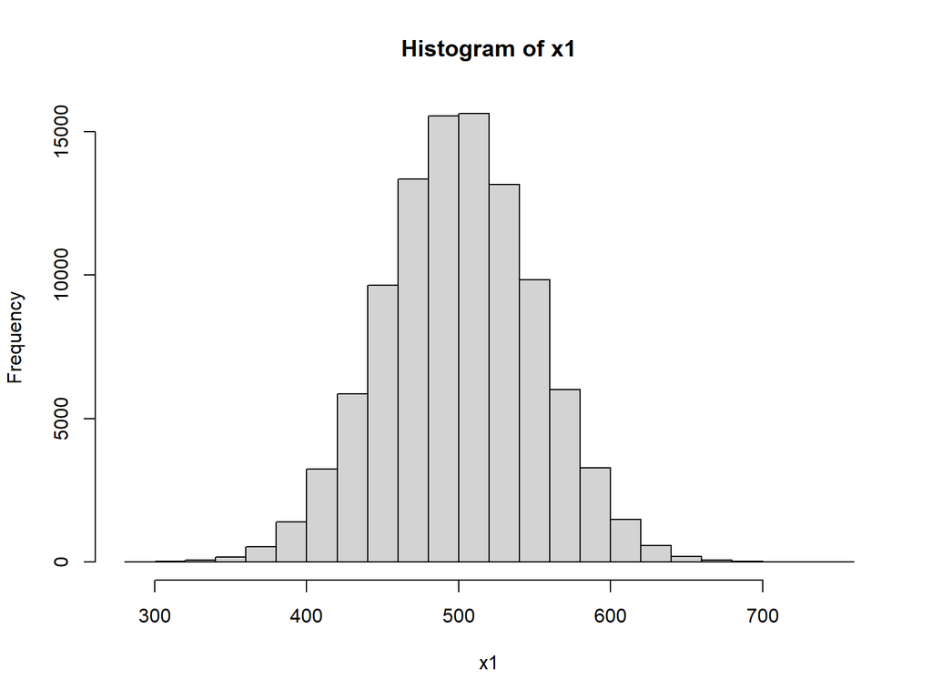

```r
hist(x1)
```

# Rozkład średniej z próby

## Pobieranie próbek z zmiennej losowej o rozkładzie normalnym z znanymi parametrami mu/sigma

Zasymulujemy ponowne pobieranie próbek….. 1000 razy:

```r
nsim<-1000 # liczba symulacji
n<-100 # liczba osbserwacji w kazdej próbie/symulacji
mu<-500 # średnia
sigma<-100 # odchylenie standardowe
samp_distrn_means<-rep(NA,nsim) # pusta zmienna 1000 pustych miejsc na symulowane średnie
samp_distrn_sd<-rep(NA,nsim) # pusta zmienna 1000 pustych miejsc na symulowane odch.std
for(i in 1:nsim){ # w każdej z tysiąca iteracji zapisanych jako jedno x
  x<-rnorm(n,mean=mu,sd=sigma) # zapisz wygenerowanych 100 obserwacji
  samp_distrn_means[i]<-mean(x) # z każdej symulowanej próbki podaj średnią i zapisz
  samp_distrn_sd[i]<-sd(x) # z każdej symulowanej próbki podaj średnią i zapisz
}
```

# Rozkład średniej z próby

## Pobieranie próbek z zmiennej losowej o rozkładzie normalnym z znanymi parametrami mu/sigma

Wykres rozkładu średnich powstały w wyniku wielokrotnego pobierania próbek:

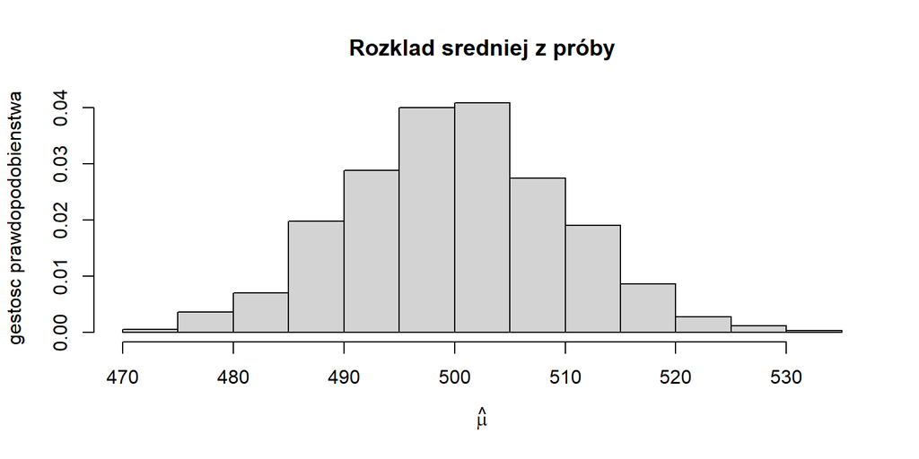

# Pobieranie próbek z zmiennej losowej o rozkładzie wykładniczym

## Rozkład średniej z próby

Co ciekawe, wcale nie jest konieczne by rozkład zmiennej losowej z której pobieramy próbki był normalny.

W tym przykładzie rozkład będzie wykładniczy:

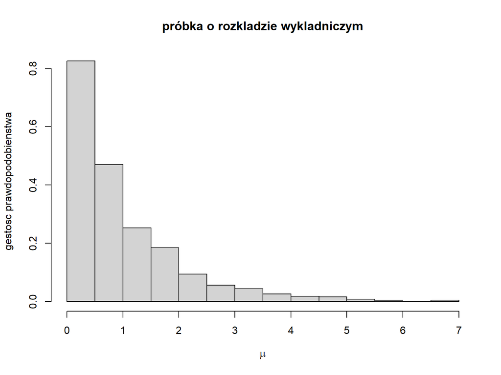

```r
x<-rexp(1000)
hist(x,main="próbka o rozkładzie wykładniczym",
     freq=F,xlab=expression(mu),ylab="gęstość prawdopodobieństwa")
```

```r
samp_distrn_means_exp<-rep(NA,nsim) # pusta zmienna 1000 pustych miejsc na symulowane średnie
samp_distrn_sd_exp<-rep(NA,nsim) # pusta zmienna 1000 pustych miejsc na symulowane odch.std
for(i in 1:nsim){
  x<-rexp(n)
  samp_distrn_means_exp[i]<-mean(x)
  samp_distrn_sd_exp[i]<-sd(x)
}
```

# Rozkład średniej z próby

## próbki pobrane z “populacji o rozkładzie wykładniczym” dla danej cechy

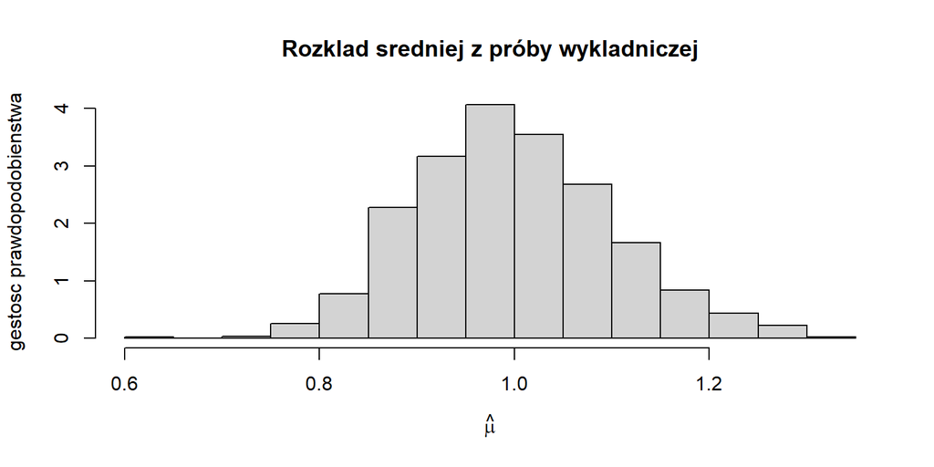

# Centralne twierdzenie graniczne

## twierdzenia:

- Przy bardzo licznym pobieraniu próbek (gdy N -> $\inf$) pochodzących z zbioru o ustalonej średniej oraz odchyleniu standardowemu, rozkład średniej z próby będzie miał w przybliżeniu rozkład normalny, niezależnie od tego jakiemu rozkładowi podlega zbiór z którgo pobieramy próbki (ważne jest tylko by zbiór ten miał zdefiniwaną średnią oraz wariancję).
- Twierdzenie to stanowi podstawę w wnioskowaniu statystycznym.

# Błąd standardowy

## Rozkład średniej z próby

Możemy obliczyć odchylenie standardowe dla rozkładu średnich z próby:

```r
## oszacowanie z symulacji:
sd(samp_distrn_means)
```

```
## [1] 9.853872
```

## Rozkład średniej z próby

Dalszym ciekawym faktem jest to, że możemy obliczyć samo odchylenie sandardowe rozkładu próby **na podstawie jednej pobranej próbki** o liczebności $n$:

$$\frac{\hat\sigma}{\sqrt{n}}$$

```r
x<-rnorm(100,mean=500,sd=100)
hat_sigma<-sd(x)
hat_sigma/sqrt(n)
```

```
## [1] 11.40958
```

# Rozkład średniej z próby

- Więc, z próbki liczącej $n$ obserwacji, oraz odchyleniu standardowemu $\sigma$ lub maksymalnie wiarygodnemu oszacowaniu (MLE) $\hat\sigma$, możemy obliczyć
- odchylenie standardowe rozkładu z próby.
- Będziemy nazywali to odchylenie standardowe oszacowaniem **błędu standardowego** lub po prostu **błędem standardowym**.

$$SE = \frac{\hat\sigma}{\sqrt{n}}$$

- mówimy tu o *oszacowaniu* ponieważ próbujemy oszacować błąd standardowy używając do tego oszacowań $\sigma$.

# Przedziały ufności

Błąd standardowy pozwoli nam na zdefiniowanie tzw. **95 % przedziału ufności**:

$$\hat\mu \pm 2 SE$$

Także , dla średniej, definiujemy *95 % przedział ufności* następująco:

$$\hat\mu \pm 2 \frac{\hat\sigma}{\sqrt{n}}$$

# Przedziały ufności

w naszym przypadku:

```r
## dolna granica przedziału:
mu-(2*hat_sigma/sqrt(n))
```

```
## [1] 477.1808
```

```r
## górna granica przedziału:
mu+(2*hat_sigma/sqrt(n))
```

```
## [1] 522.8192
```

## znaczenie 95 % przedziału ufności

Jeżeli będziesz powtarzał pobieranie próbek i dla każdej pobranej próbki obliczał przedział ufności, 95 % tych przedziałów ufności będzie zawierało prawdziwą wartość średniej populacji.

```r
lower<-rep(NA,nsim)
upper<-rep(NA,nsim)
for(i in 1:nsim){
  x<-rnorm(n,mean=mu,sd=sigma)
  lower[i]<-mean(x) - 2 * sd(x)/sqrt(n)
  upper[i]<-mean(x) + 2 * sd(x)/sqrt(n)
}
```

# znaczenie 95 % przedziału ufności

```r
## sprawdzimy ile przedziałów ufności zawiera prawdziwą średnią :
CIs<-ifelse(lower<mu & upper>mu,1,0)
table(CIs)
```

```
## CIs
##   0   1
##  57 943
```

```r
## w przyblizeniu 95% przedziałów ufności zawiera prawdziwą średnią:
table(CIs)[2]/sum(table(CIs))
```

```
##     1
## 0.943
```

## znaczenie 95 % przedziału ufności

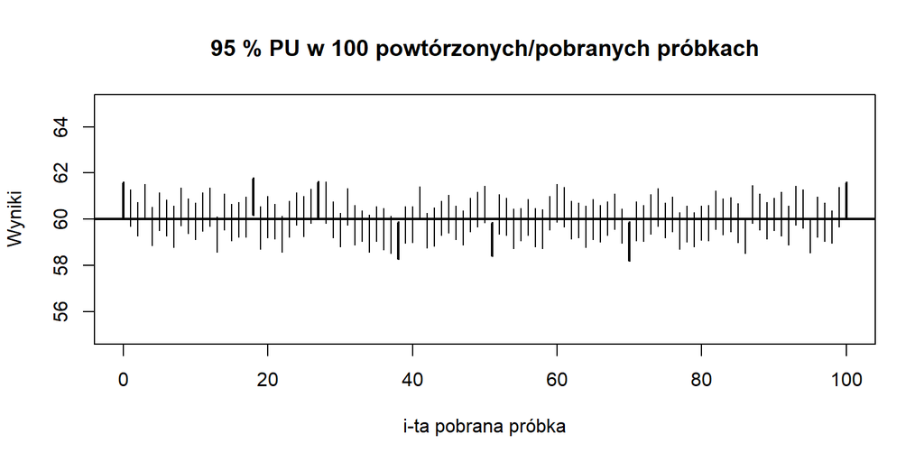

# znaczenie 95 % przedziału ufności

- 95 % PU z konkretnej próbki **nie** oznacza prawdopodobieństawa, że prawdziwa wartość średniej z populacji znajduje się w obrębie tego szczególnego PU.
- Dlatego, PU ma bardzo mylącą (niezbyt użyteczną!) interpretację.
- W statystyce Bayesowskiej używa się przedziałów wiarygodności, które posiadają o wiele sensowniejszą interpretację.

Niemniej, rzy dużych liczebnościach próby, przedział wiarygodności oraz ufności iw zasadzie są takie same.

Z tego powodu też, PU jest często wykorzystywany (technicznie jest to niepoprawne!) do opisu niepewności naszego oszacowania średniej.

# Najważniejsze “informacje do zapamiętania” z tego wykładu

- Możemy obliczyć oszacowania maksymalnej wiarygodności (MLE) średniej $\bar{x}=\hat\mu$ oraz odchylenia standardowego $\hat\sigma$ żeby oszacować prawdziwe lecz nieznane parametry w populacji.

$$\bar{x} = \frac{\sum_{i=1}^n x_i}{n}$$
* Dla danej próbki, po oszacowaniu $\hat\sigma$, możemy oszacować błąd standardowy:

$$SE=\hat\sigma/\sqrt{n}$$
* to pozwala nam na zdefiniowanie 95 % PU dla oszacowania średniej:

$$\hat \mu \pm 2\times SE$$
Posiadając te informacje możemy teraz przejść do wnioskowania statystycznego i testowania hipotez, a właściwie testowania hipotezy zerowej (NHST - Null Hypothesis significance testing)

# O czym ważnym mówilismy do tej pory

- Zdefiniowaliśmy czym jest zmienna losowa.
- Wiemy czym jest gęstość prawdopodobieństwa (PDF) oraz prawdopodobieństwo skumulowane (CDF), i wiemy jak obliczyć $P(X<x)$.
- Wiemy czym jest oszacowanie maksymalnej wiarygodności.
- Wiemy czym jest Rozkład średniej z próby.

To daje nam podstawy by zrozumieć zasadę działania null hypothesis significance testing (NHST).

# Wnioskowanie ststystyczne

## Testowanie hipotez

Założmy że mamy losową próbkę o liczebności $n$, a dane pochodzą z rozkładu $N(\mu,\sigma)$ ….. normalnego.

Możemy oszacować średnią dla próbki $\bar{x}=\hat \mu$ oraz $\hat\sigma$, co w następnje kolejności pozwala nam oszacować Rozkład średniej z prób przy (hipotetycznym) powtarzanym próbkowaniu:

$$N(\bar{x},\frac{\hat \sigma}{\sqrt{n}})$$

# Testowanie hipotez dla jednej próby

Wyobraźny sobie, że pobieramy **niezależną** losową próbkę z zmiennej losowej X, która ma rozkład normalny, z średnią wynoszącą 12 oraz odchyleniem standardowym, które wynosi 10, liczebność próby to 11. Oszacowujemy średnią oraz błąd standardowy:

```r
probka <- rnorm(11,mean=12,sd=10)
(x_bar<-mean(probka))
```

```
## [1] 10.21603
```

```r
(SE<-sd(probka)/sqrt(11))
```

```
## [1] 2.007215
```

# test-t dla jednej próby

Podejście jakim jest testowanie hipotezy zerowej polega na postawieniu hipotezy zerowej która mówi, że średnia $\mu$ ma jakąś ustaloną wartość. Na przykład:

$$H_0: \mu = 0$$

Sprowadza się to do założenia, że prawdziwe rozkłady średnich z próby (w przybliżeniu ^) są normalne a ich środek znajduje się wokół zera *z błędem standardowym oszacowanym na podstawie próbki*.

^ za chwilę wyjaśnimy to sobie bardziej precyzyjnie.

# rozkład dla Hipotezy zerowej H0

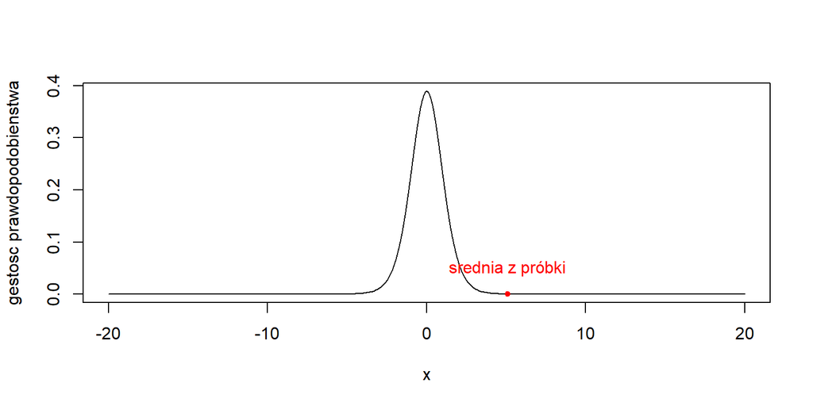

# NHST Null Hypothesis Significance Testsing - Testowanie istotności przy pomocy hipotezy zerowej

Intuicyjnie rzecz biorąc cały pomysł polega na tym że:

- jeżeli średnia z próbki $\bar{x}$ jest blisko hipotetycznemu $\mu$ (tutaj, 0), to dane są (być może) “spójne” z rozkładem dla hipotezy zerowej H0.
- jeżeli średnia z próbki $\bar{x}$ jest daleko od hipotetycznego $\mu$, to dane nie są (być może) “spójne” z rozkładem dla hipotezy zerowej H0. ^

Formalizujemy ‘’blisko’’ oraz ‘’daleko’’ poprzez ustalenie o ile błędów standardowych oddalona jest średnia z próbki (H1) od hipotetycznej średniej zerowej (HO):

$$t \times SE = \bar{x} - \mu$$

W ten sposób kwantyfikujemy dystans średniej z próbki od $\mu$ w jednostkach błędu standardowego średniej.

^ hipoteza zerowa to na przykład twierdzenie: że różnica między grupą kontrolną i eksperymentalną wynosi 0; Albo, że średnie IQ w populacji dzieci z trudnościami w uczeniu to 90.

# NHST Null Hypothesis Testsing - Testowanie istotności przy użyciu hipotezy zerowej

Więc, dysponując średnią z próbki oraz średnią dla hipotezy zerowej $\mu$, możemy oszacować statystykę T:

$$t = \frac{\bar{x} - \mu}{SE}$$

Nazwiemy to **Statystyką/wartością T**. Jak ważny jest to wskaźnik stanie się zaraz jasne.

Dysponując tą wartością możemy obliczyć prawdopodobieństwo otrzymania średniej jak w naszej próbce $\bar{x}$ (lub też jeszcze bardziej ekstremalny, czytaj wyższy wynik), przy hipotezie zerowej H0.

# NHST Null Hypothesis significance Testsing - Testowanie instotnosci przy użyciu hipotezy zerowej

Wartość:

$$T = \frac{\bar{X} - \mu}{SE}$$

podlega rozkładowi T-Studenta, który jest zdefiniowany poprzez liczebność próby $n$. wyrazimy to w sposób następujący: $T \sim t(n-1)$

Warto wtym miejscu zapamiętać, że dla dużych $n$, $T\sim N(0,1)$.

# NHST Null Hypothesis significance Testsing - Testowanie instotnosci przy użyciu hipotezy zerowej

Więc przy danej wielkości próbki $n$, oraz zakładając prawdziwość hipotezy zerowej H0 , możemy użyć rozkładu T-studenta odpowiadającego rozkładowi hipotezy zerowej H0.

Dla dużych $n$, moglibyśmy nawet użyć rozkładu noermalnego N(0,1), niemniej przy porównywaniu 2 średnich jest tradycją w psychologii, żeby używać rozkładu T-Studenta niezalżnie od liczebności próbek $n$.

# Rozkład normalny a rozkład T-Studenta

- Rozkład T-Studenta ma jako parametr stopnie swobody $n-1$, gdzie $n$ oznacza liczebność próby (w porównaniu z rozkładem normalnym, który jako parametry ma śrenią oraz wariancję/odchylenie satndardowe).
- Rozkład T-Studenta przy niewielkich liczebnościach $n$ powiedzmy $n<20$ ma “grubsze ogony” w porównaniu z rozkładem normalnym , lecz przy większej liczebnosci próby, Rozkład T-Studenta oraz rozkład normalny są w zasadzie identyczne.

# Rozkład normalny a rozkład T-Studenta

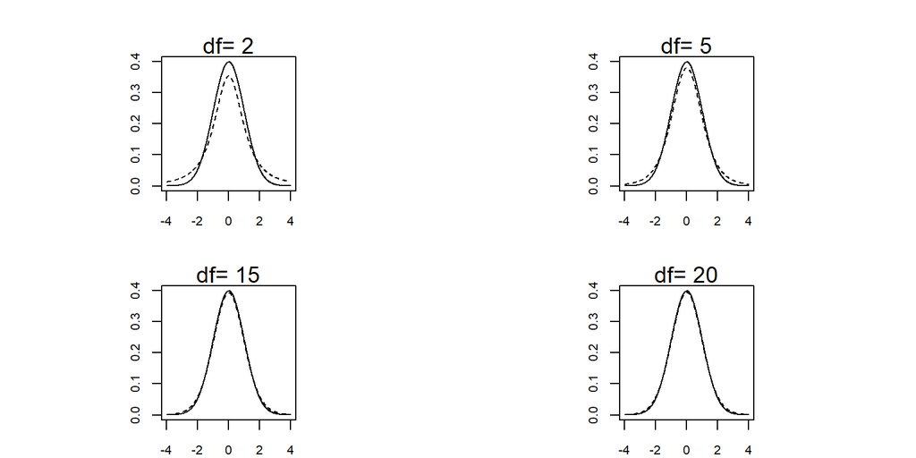

# Test T-Studenta “obszar odrzucenia”

Tak więc, procedura testowania hipotezy zerowej polega na:

- Zdefiniuj hipotezę zerową H0: na przykład, $H_0: \mu = 0$.
- Przy określonej liczebności $n$, oszacuj średnią $\bar{x}$, odchylenie standardowe $s$, błąd standardowy $s/\sqrt{n}$.
- Oblicz wartość T:

$$t=\frac{\bar{x}-\mu}{s/\sqrt{n}}$$

- Odrzuć hipotezę zerową gdy wartość T jest duża (zaraz sprecyzujemy co oznacza duża).

# Test T-Studenta

W jaki sposób zadecydować o odrzuceniu hipotezy zerowej? Intuicyjnie, gdy wartość T z próby jest na tyle duża, że lokuje się daleko w *którymkolwiek* ogonie rozkładu.

# Test T-Studenta

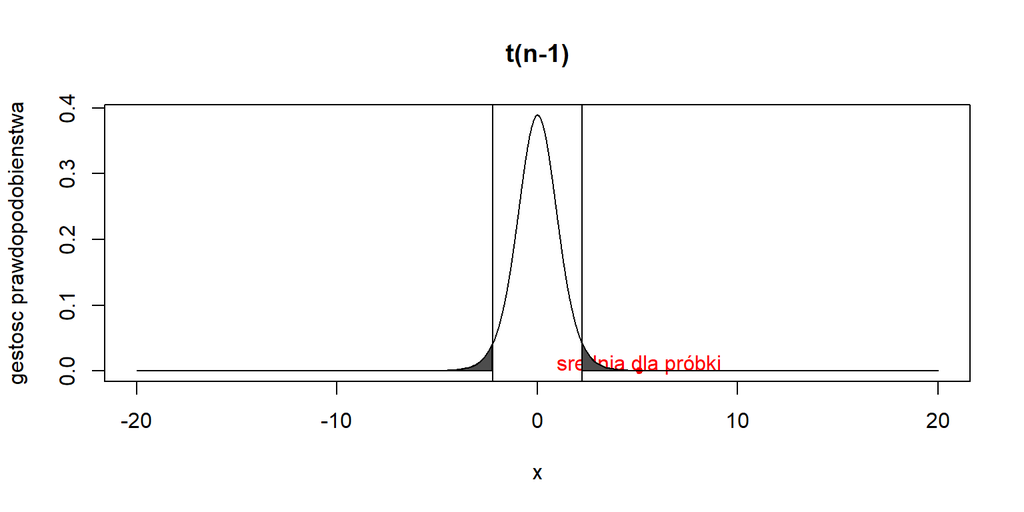

# Test T-Studenta “obszar odrzucenia”

- Dla określonej liczbności N próbki, możemy ustalić “obszar odrzucenia” używając do tego funkcji qt -odwróconej dystrybuanty" (patrz wykład wprowadzający1).
- Ponieważ kształt rozkładu T-Studenta zależy od stopni swobody (n-1), **krytyczna wartość T** powyżej której odzrzucamy hipotezę zerową HO, będzie inna w zależności od wielkości próby.
- Dla dużych liczebności, powiedzmy $n>50$, punkt odrzucenia wynosi coś około 2.

```r
abs(qt(0.025,df=15))
```

```
## [1] 2.13145
```

```r
abs(qt(0.025,df=50))
```

```
## [1] 2.008559
```

# Test T-Studenta “obszar odrzucenia”

Rozważmy wartość T z próbki w przykładzie, którego cały czas używamy:

```r
## średnia hipotezy zerowej:
mu<-0
x_bar
```

```
## [1] 10.21603
```

```r
(t_value<-(x_bar-mu)/SE)
```

```
## [1] 5.089657
```

Przypomnijmy sobie,że wartość T dla próbki odzwierciedlająca położenie średniej z tejże mówi nam o niczym więcej jak o odległości średniej z próbki od średniej dla hipotezy zerowej H0 $\mu$ w jednostkach błędu standardowego.

$$t=\frac{\bar{x}-\mu}{s/\sqrt{n}} \hbox{ lub } t\frac{s}{\sqrt{n}}=\bar{x}-\mu$$

# Test T-Studenta “obszar odrzucenia”

Więc przy dużych liczebnościach próbek, jeżeli $\mid t\mid >2$ (w przybliżeniu), mozemy odrzucić hipotezę zerową H0.

Przy mniejszych liczebnościach $n$ próbek, możesz obliczyć wartość krytyczną T:

*qt(0.025,df=n-1)*

jest to krytyczna wartość T po **lewej** stronie rozkładu T-Studenta. Odpowiednią wartością po prawej stronie wyrazimy następująco:

*qt(0.975,df=n-1)*

Ich wartości bezwzględne są oczywiście identyczne (rozkład jest symetryczny).

# Rozkład normalny a rozkład T-Studenta

Biorąc pod uwagę określoną wartość stopni swobody, możemy obliczyć obszar pod funkcją gęstości prawdopodobieństwa tak samo jak w przypadku rozkładu normalnego:

```r
pt(-2,df=10)
```

```
## [1] 0.03669402
```

```r
pt(-2,df=20)
```

```
## [1] 0.02963277
```

```r
pt(-2,df=50)
```

```
## [1] 0.02547353
```

Gdy stopnie swobody przyjmują duże wartości, obszr pod funkcją na lewą stronę od -2 wyności w przybliżeniu 0.025.

# Rodzaje testów T-Studenta

- test - T Studenta dla jednej próby
- test - T Studenta dla prób niezależnych ** test -T Studenta równe wariancje ** test -T Studenta nierówne liczebności,zbliżone wariancje ** test -T Welcha nierówne liczebności,nierówne wariancje
- test - T Studenta dla prób zależnych (pomiarów powtarzanych)
- nieparametryczny test - dla prób niezależnych (Whitney-Mann U, $\chi^2$ Fishera)
- nieparametryczny test - dla prób zależnych (Wilcoxona, Mcnamary)

# wybór testu drzewo decyzyjne

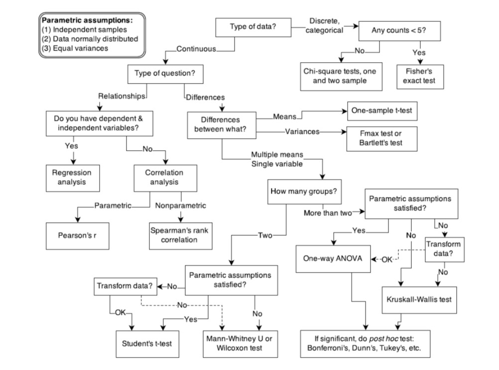

# wybór testu drzewo decyzyjne

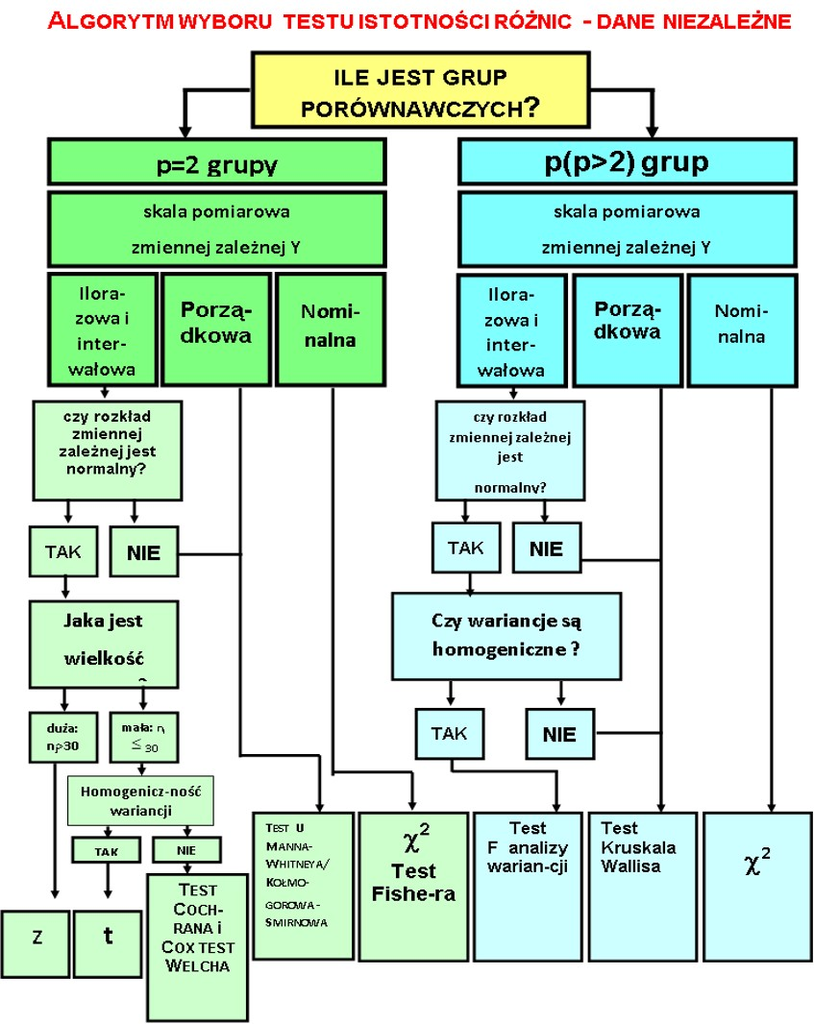

# wybór testu drzewo decyzyjne

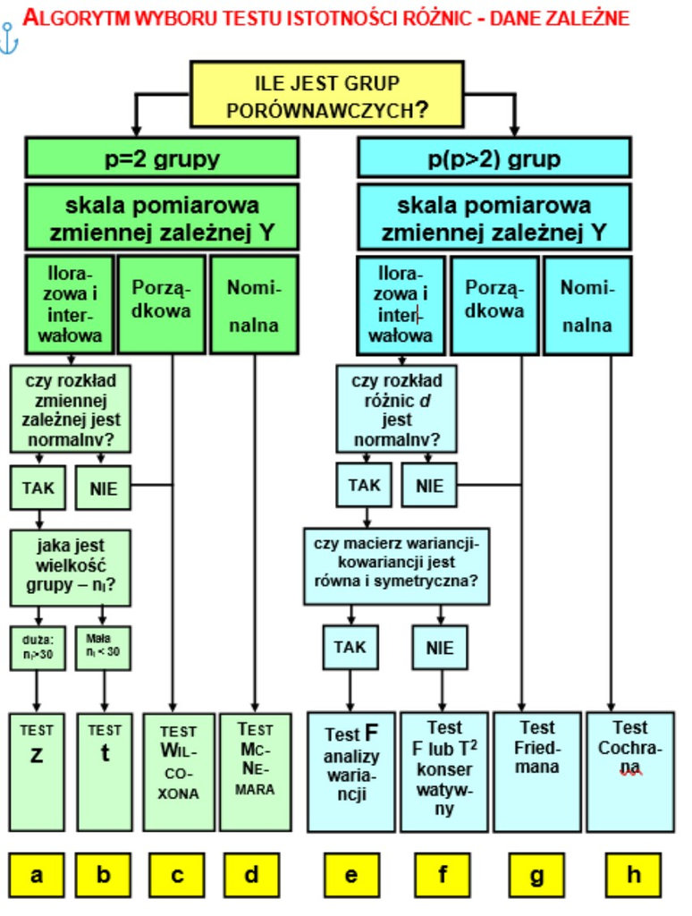

# Ogólna idea testowania istotności hipotezy zerowej -jeszcze raz

- każda statystyka testowa (jak np. $Z, t, F, \chi^2,V,r$) posiada sprzypisany jej rozkład prawdopodobieństwa
- wartości statystyk wyrażają najczęściej stosunek efektu eksperymentalnego do miary błędu jak n.p. odchylenie standardowe. W przypadku **t (test t-Studenta)** mamay stosunek: różnica średnich / dzielona przez / jakiś rodzaj błędu standardowego. W przypadku **F (ANOVA)** mamy stosunek: suma kwadratów modelu (odchylenie średnich grupowych od ogólnej średniej) / dzielona przez / suma kwadratów odchyleń konkretnych osób od ich średniej grupowej.
- dla **każdej wartości** którejkolwiek z statystyk można określić prawdopodobieństwo skumulowane dla tej właśnie oraz wszystkich od niej mniejszych wartości w odpowiednim przypisanym do nich rozkładzie prawdopodobieństwa, któremu podlegają.

# Ogólna idea testowania istotności hipotezy zerowej -jeszcze raz

- Przyjrzyjmy się temu na przykładzie wartości t dla powtarzanych pomiarów/ manipulacji wewnątrzgrupowej / pretest-posttest
- Wzór do obliczenia wartości t:
  $$t = \frac{\bar{X}_D - \mu_0}{s_D/\sqrt n}$$
- gdzie **$\bar{X}_D$** to średnia róznicy; **$\mu_0$** to wartość różnicy gdyby przyjąć H0 czyli założenie że w populacji różnica między grupami wynosi dokładnie 0:); a **$s_D/\sqrt n$** to odchylenie standardowe różnicy podzielone przez pierwiastek z liczbności próby ….czyli …. błąd standardowy (patrz wcześniej w tym wykładzie - slajd 1 do 9=` test - T Studenta dla jednej próby
- do tego celu wygenerujemy sobie 6 zestawów danych:
- 3 z małą różnicą między średnimi: x1:90 x2:92 i podobnych odch. std. około 20
- 3 z większą różnicą między średnimi: x1:90 x2:100 i podobnych odch. std. około 20

# Ogólna idea testowania istotności hipotezy zerowej -jeszcze raz

## zobaczmy parametry wygenerowanych danych

Dane losowo wygenerowane - mala róznica X,Y

|  | V1sr | V1odch | V2sr | V2odch | V3sr | V3odch |
| --- | --- | --- | --- | --- | --- | --- |
| N | 10 | 10 | 100 | 100 | 10000 | 10000 |
| Parametry | sr | odch_std | sr | odch_std | sr | odch_std |
| X | 93.4 | 21.5 | 93.6 | 23.9 | 92 | 22.9 |
| Y | 89.8 | 28.9 | 90.9 | 22.4 | 90 | 22.8 |

Dane losowo wygenerowane - duza róznica X,Y

|  | V4sr | V4odch | V5sr | V5odch | V6sr | V6odch |
| --- | --- | --- | --- | --- | --- | --- |
| N | 10 | 10 | 100 | 100 | 10000 | 10000 |
| Parametry | sr | odch_std | sr | odch_std | sr | odch_std |
| X | 104.2 | 20.2 | 102.4 | 24.7 | 100.4 | 22.5 |
| Y | 89.7 | 20.5 | 92 | 23.9 | 90.1 | 22.5 |

# Ogólna idea testowania istotności hipotezy zerowej -jeszcze raz

## zobaczmy Histogramy zmiennej różnica oraz……………..

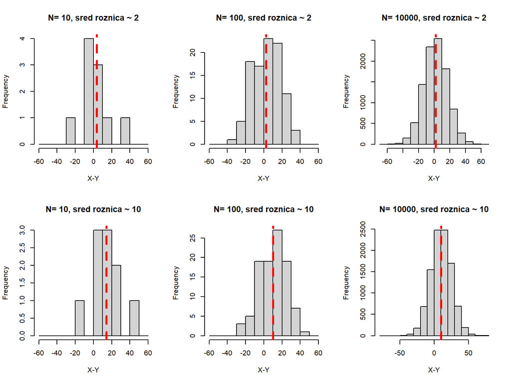

# Ogólna idea testowania istotności hipotezy zerowej -jeszcze raz

## ……….oraz parametry dla 6 średnich różnic

$$t = \frac{\bar{X}_D - \mu_0}{s_D/\sqrt n}$$

Dane wygenerowane losowo - róznica X-Y

|  | Para1 | Para2 | Para3 | Para4 | Para5 | Para6 |
| --- | --- | --- | --- | --- | --- | --- |
| N | 10 | 100 | 10000 | 10 | 100 | 10000 |
| df | 9 | 99 | 9999 | 9 | 99 | 9999 |
| sred_roz | 3.6 | 2.7 | 2 | 14.5 | 10.4 | 10.3 |
| odch_std_roz | 14.29 | 15.27 | 15.05 | 16.6 | 14.63 | 14.96 |
| blad_std | 4.52 | 1.53 | 0.15 | 5.25 | 1.46 | 0.15 |
| T_stat | 0.8 | 1.76 | 13.57 | 2.76 | 7.09 | 68.64 |
| p_value | 0.443 | 0.081 | 0 | 0.022 | 0 | 0 |

# Rozkłady gęstości prawd. t-Studenta z różnymi (df = 9; 99; 9999) stopniami swobody

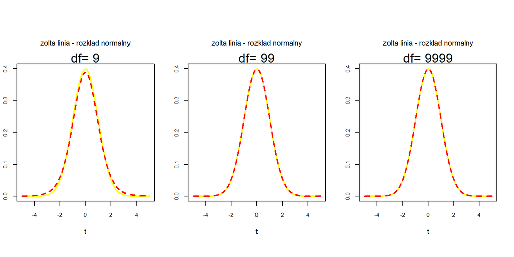

# Rozkłady skumulowanego prawd.t-Studenta z różnymi (df = 9; 99; 9999) stopniami swobody

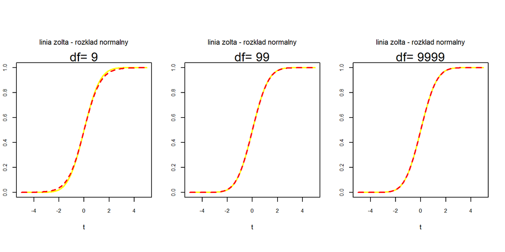

# Skumulowane prawdopodobieństwo i istotność

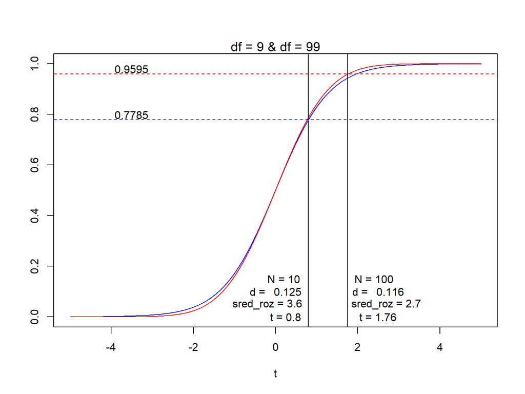

```r
p_value[1]/2 # istotność: 1-stronne prawdopodob.
```

```
## [1] 0.2215
```

```r
p_value[2]/2 # istotność: 1-stronne prawdopodob.
```

```
## [1] 0.0405
```

```r
p_value[1] # istotność: 2-stronne prawdopodob.
```

```
## [1] 0.443
```

```r
p_value[2] # istotność: 2-stronne prawdopodob.
```

```
## [1] 0.081
```

```r
t.test(dane1$x,dane1$y,paired = TRUE)
```

```
##
##  Paired t-test
##
## data:  dane1$x and dane1$y
## t = 0.80251, df = 9, p-value = 0.4429
## alternative hypothesis: true difference in means is not equal to 0
## 95 percent confidence interval:
##  -6.598253 13.853710
## sample estimates:
## mean of the differences
##                3.627729
```

```r
t.test(dane2$x,dane2$y,paired = TRUE)
```

```
##
##  Paired t-test
##
## data:  dane2$x and dane2$y
## t = 1.7607, df = 99, p-value = 0.08139
## alternative hypothesis: true difference in means is not equal to 0
## 95 percent confidence interval:
##  -0.3413908  5.7185524
## sample estimates:
## mean of the differences
##                2.688581
```

# Skumulowane prawdopodobieństwo i istotność

## to samo z perspektywy rozkładu gęstości prawd.

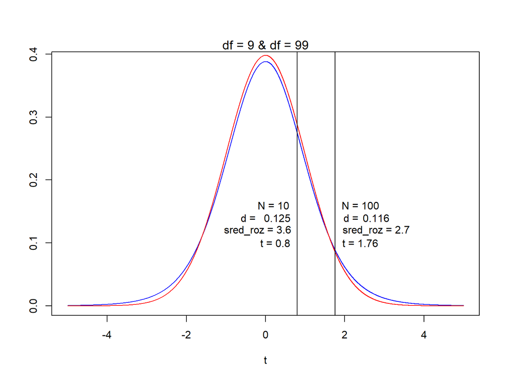

# Rozkłady t-Studenta dla małej różnicy (~2) oraz 9;99,9999 df

## odległość wartości t od 0 i prawdopodbieństwo t pod rozkładem H0

- Proszę zwrócić uwagę, że wielkość efektu (standaryzowana różnica) jest prawie taka sama a nawet wręcz maleje
- Podsumowując: sedno istotności to jakby “informacja ile wynosi szansa, że nie zarobię 0 PLN” :) i tylko tyle
- Wielkość efektu (ile zarobię) o wiele ciekawsza; oraz prawdopodoieństwo beta (błąd II rodzaju)

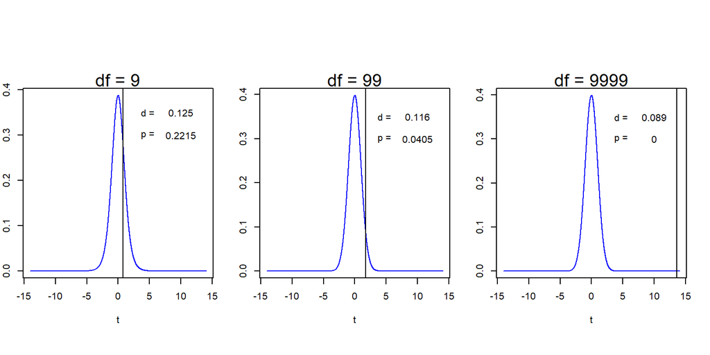

# Typy testów t

## test dla jednej próby

$$t = \frac{\bar{X_D} - \mu_0}{s/\sqrt n}$$

- gdzie $\bar{X_D}$ to różnica między średnią z próbki a średnią populacyjną
- gdzie $s$ to odchylenie standardowe dla próbki
- Test stosujemy w przypadku gdy chcemy sprawdzić czy różnica między nasza próbka a jakąś znaną/ustaloną/ założoną wartością w poulacji jest istotna ststystycznie.

# Typy testów t

## test dla prób niezależnych

gdy grupy są równoliczne oraz prawie identyczne

$$t = \frac{\bar{X}_1 - \bar{X}_2}{s_p \sqrt\frac{2}{n}}$$

gdzie

$$s_p = \sqrt{\frac{s_{X_1}^2+s_{X_2}^2}{2}}$$

# Typy testów t

## test dla prób niezależnych

- równe i nierówne liczbności grup oraz w miarę podobne wariancje ($\frac{1}{2} < \frac{s_{x_1}}{s_{x_2}} < 2$)

$$t = \frac{\bar {X}_1 - \bar{X}_2}{s_p \cdot \sqrt{\frac{1}{n_1}+\frac{1}{n_2}}}$$
gdzie
$$s_p = \sqrt{\frac{\left(n_1-1\right)s_{X_1}^2+\left(n_2-1\right)s_{X_2}^2}{n_1+n_2-2}}$$
to wspólna wariancja

# Typy testów t

## test dla prób niezależnych - Test Welcha różne liczbnosci grup i nierówne wariancje

- nierówne wariancje $s_{X_1} > 2s_{X_2}$ lub $s_{X_2} > 2s_{X_1}$
- W SPSSie podajemy Test Welcha
- Niektórzy twierdzą, że z powodu braku czułości testu Levena na mierówność wariancji właściwie powinno się wykonywać tylko test T-Welcha dla grup niezależnych

$$t = \frac{\bar{X}_1 - \bar{X}_2}{s_{\bar\Delta}}$$
gdzie
$$s_{\bar\Delta} = \sqrt{\frac{s_1^2}{n_1} + \frac{s_2^2}{n_2}}$$
* Stopnie swobody

$$\mathrm{df} = \frac{\left(\frac{s_1^2}{n_1} + \frac{s_2^2}{n_2}\right)^2}{\frac{\left(s_1^2/n_1\right)^2}{n_1-1} + \frac{\left(s_2^2/n_2\right)^2}{n_2-1}}$$

# Typy testów t

## test dla prób niezależnych - nieparametryczny Test U-Manna Withneya

brak spełnionych załozeń

- normalności
- zmienne porządkowe zamiast ilościowych

$$U_1=R_1 - {n_1(n_1+1) \over 2}$$
$$U_2=R_2 - {n_2(n_2+1) \over 2}$$
$$U_1 + U_2 = R_1 - {n_1(n_1+1) \over 2} + R_2 - {n_2(n_2+1) \over 2}$$

- gdzie $U_1$ lub $U_2$ to łączna możliwa suma rang minus empiryczna suma rang dla grupy 1 oraz 2 odpowiednio
- Pdawane jest mniejsze U jako statystyka
- H0: $U_1 = U_2$
- dla konkretnych liczbności $n_1$ oraz $n_2$ wartości krytyczne mniejszego $U$

# Typy testów t

## test dla prób niezależnych - nieparametryczny Test U-Manna Withneya

Grupy niezalezne: Dane porangowane

| Stary_typ | Nowy_typ | Stary_typ_sort | Nowy_typ_sort | Stary_typ_rang | Nowy_typ_rang |
| --- | --- | --- | --- | --- | --- |
| 8 | 9 | 2 |  | 1 |  |
| 7 | 8 | 3 |  | 2 |  |
| 6 | 7 | 5 |  | 3 |  |
| 2 | 8 | 6 | 6 | 4.5 | 4.5 |
| 5 | 10 | 7 | 7 | 7 | 7 |
| 8 | 9 | 7 |  | 7 |  |
| 7 | 6 | 8 | 8 | 10.5 | 10.5 |
| 3 |  | 8 | 8 | 10.5 | 10.5 |
|  |  |  | 9 |  | 13.5 |
|  |  |  | 9 |  | 13.5 |
|  |  |  | 10 |  | 15 |
|  |  |  |  | R1=45.5 | R2=74.5 |

# Typy testów t

## test dla prób niezależnych - nieparametryczny Test U-Manna Withneya

- $U_1=R_1 - {n_1(n_1+1) \over 2}$ ; $U_2=R_2 - {n_2(n_2+1) \over 2}$
- $9.5=45.5- {8(9) \over 2}$ ; $46.5=74.5 - {7(8) \over 2}$

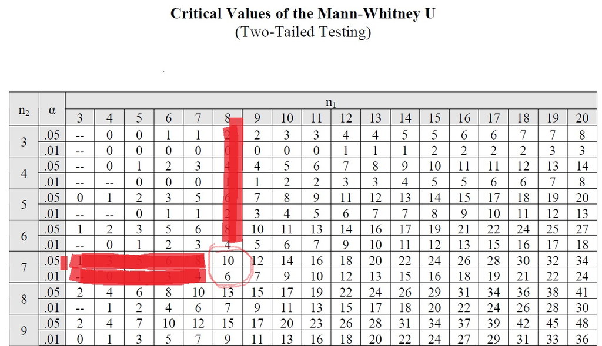

# Typy testów t

## test dla prób niezależnych - nieparametryczny Test Chi^2 Fishera

- dwie grupy niezależne
- zmienne nominalne

Czy M i K po równo na Uniwersytecie

|  | Faceci | Kobiety | Wiersz total |
| --- | --- | --- | --- |
| Studiuje | 1 | 9 | 10 |
| NieStudiuje | 11 | 3 | 14 |
| Kolumna_total | 12 | 12 | 24 |

# Typy testów t

## test dla prób niezależnych - nieparametryczny Test Chi^2 Fishera

Czy M i K po równo na Uniwersytecie

|  | Faceci | Kobiety | Wiersz total |
| --- | --- | --- | --- |
| Studiuje | a | b | a+b |
| NieStudiuje | c | d | c+d |
| Kolumna_total | a+c | b+d | a+b+c+d(=n) |

- jak obliczyć prawdopodobieństwo, że proporcje nie są zerowe:

$$p = \frac{ \displaystyle{{a+b}\choose{a}} \displaystyle{{c+d}\choose{c}} }{ \displaystyle{{n}\choose{a+c}} } = \frac{ \displaystyle{{a+b}\choose{b}} \displaystyle{{c+d}\choose{d}} }{ \displaystyle{{n}\choose{b+d}} } = \frac{(a+b)!~(c+d)!~(a+c)!~(b+d)!}{a!~~b!~~c!~~d!~~n!}$$

$$p = { {\tbinom{10}{1}} {\tbinom{14}{11}} }/{ {\tbinom{24}{12}} } = \tfrac{10!~14!~12!~12!}{1!~9!~11!~3!~24!} \approx 0.001346076$$

# Typy testów t

## test dla prób zależnych / pomiarów powtarzanych

$$t = \frac{\bar{X}_D - \mu_0}{s_D/\sqrt n}$$

- gdy rozkłady zmiennych są normalne
- zmienne mają charakter ilościowy

# Typy testów t

## test dla prób zależnych / pomiarów powtarzanych - Test Wilcoxona

- brak normalności
- zmienne porządkowe

Dane Powtarzane: zródlo Wikipedia

| Osoba | Pomiar1 | Pomiar2 | Znak_roz | Abs_roz | Ranga_roz | Ranga_roz_znak |
| --- | --- | --- | --- | --- | --- | --- |
| 5 | 140 | 140 | 0 |  |  |  |
| 3 | 130 | 125 | 1 | 5 | 1.5 | 1.5 |
| 9 | 140 | 135 | 1 | 5 | 1.5 | 1.5 |
| 2 | 115 | 122 | -1 | 7 | 3 | -3 |
| 6 | 115 | 124 | -1 | 9 | 4 | -4 |
| 10 | 135 | 145 | -1 | 10 | 5 | -5 |
| 8 | 125 | 137 | -1 | 12 | 6 | -6 |
| 1 | 125 | 110 | 1 | 15 | 7 | 7 |
| 7 | 140 | 123 | 1 | 17 | 8 | 8 |
| 4 | 140 | 120 | 1 | 20 | 9 | 9 |

# Typy testów t

## test dla prób zależnych / pomiarów powtarzanych - Test Wilcoxona

- Statystyka W:

$$W = \sum_{i=1}^{N_r} [\znak(x_{2,i} - x_{1,i}) \cdot R_i]$$
, suma rang z znakiem

- Przykład na danych z Wiki:
  $$W = 1.5+1.5-3-4-5-6+7+8+9=9$$
  $$W| < W_{\operatorname{kryt}(\alpha = 0.05,\ 9 \text{, 2-stronny})} = 15$$
  $$p = 0.6113$$

# Typy testów t

## test dla prób zależnych / pomiarów powtarzanych - Test Mcnemary

brak normalności zmienne nomianalne: odpowiedzi tak/nie

- Plan pretest postest, a odpowiedzią jest “tak” lub “nie” na to samo pytanie
- PRE: palisz papierosy? - TAK = Interwencja:Odwyk = POST: palisz papierosy? - NIE

```r
library(tidyverse)
## wczytujemy dane i nazywamy skrótowo PRE i POST
binary_pre_post <-read.table("daneszpital.txt",
                              header=T, sep = "\t", dec = ",",
                              na.strings=c(""," ","NA")) %>%
  rename("PRE" = X14..ogolne.poczucie..ze.moze.mi.pomoc, "POST" = X13..ogolne.poczucie..ze.moze.mi.pomoc)
glimpse(binary_pre_post)
```

```
## Rows: 98
## Columns: 2
## $ PRE  <int> 0, 0, 1, 1, 0, 1, 1, 1, 0, 1, 1, 0, 0, 1, 0, 1, 0, 0, 0, 0, 0, 0,~
## $ POST <int> 0, 1, 1, 0, 0, 0, 1, 1, 0, 0, 0, 0, 0, 1, 0, 1, 0, 0, 0, 0, 1, 0,~
```

# Test McNemary Chi^ dla prób zależnych

- Tworzymy tabelę krzyżową
- W tym teście, wszystko czego potrzebujemy to liczba zmian:
- z 0 na 1 - nazywamy N01
- z 1 do 0, nazywamy N10.
- Całkowita liczba zmian wynosi zatem n01 + n10, a ponieważ zgodnie z hipotezą zerową zmiany w każdym kierunku są równie prawdopodobne, możemy powiedzieć, że oczekiwana liczba zmian w każdym kierunku wynosi (n01 + n10) / 2. w tym konkretnym przypadku zmiana z 1 na 0 = 23 (n10) a z 0 na 1 = 8 (n01); oczekiwana to 31/2 = 15,5.

```r
contingency_table<-table(binary_pre_post)
contingency_table
```

```
##    POST
## PRE  0  1
##   0 37  8
##   1 23 30
```

```r
n00<-contingency_table[1,1] ## pre 0 post 0
n10<-contingency_table[2,1] ## pre 1 post 0
n01<-contingency_table[1,2] ## pre 0 post 1
n11<-contingency_table[2,2] ## pre 1 post 1

# patrzamy
Contg_table_cells <- as.data.frame (c(n00, n10, n01, n11))
Contg_table_cells
```

```
##   c(n00, n10, n01, n11)
## 1                    37
## 2                    23
## 3                     8
## 4                    30
```

# Test McNemary Chi^ dla prób zależnych

- Czy liczba zmian przekracza 10? Tak! Przekracza. Możemy liczyć Mcnemarę:)
- Jeżeli nie przekracza -> dokładny test dwumianowy, nie będę go pokazywał

```r
print(paste('n01 + n10 = ',n01+n10))
```

```
## [1] "n01 + n10 =  31"
```

Liczymy statystyki Chi^ oraz p-value H0 można odrzucić:) a czy kierunek zmian jest zgodny z “hipotezami” to już inna Bajka:)

```r
test_statistic<-(abs(n10-n01)-1)^2/(n10+n01)
p_value<-pchisq(test_statistic,df=1,lower.tail=FALSE)

test_statistic
```

```
## [1] 6.322581
```

```r
p_value
```

```
## [1] 0.011921
```

```r
contingency_table<-table(binary_pre_post)
mcnemar.test(contingency_table)
```

```
##
##  McNemar's Chi-squared test with continuity correction
##
## data:  contingency_table
## McNemar's chi-squared = 6.3226, df = 1, p-value = 0.01192
```